# pa3

Francisco Orejarena

February 13, 2018

# Third Assignment

I timed this very very poorly, so I am using the regression practice we did in class as a template.

The following is the data that I am choosing to discuss.

```r
library(languageR)
library(tidyverse)
str(beginningReaders)
```

```
## 'data.frame':    7923 obs. of  13 variables:
##  $ Word              : Factor w/ 184 levels "avontuur","baden",..: 1 1 1 1 1 1 1 1 1 1 ...
##  $ Subject           : Factor w/ 59 levels "S10","S12","S13",..: 14 25 23 43 34 26 21 28 39 24 ...
##  $ LogRT             : num  7.41 8.07 6.74 7.02 7.17 ...
##  $ Trial             : int  190 298 172 295 74 446 94 415 342 361 ...
##  $ OrthLength        : int  8 8 8 8 8 8 8 8 8 8 ...
##  $ LogFrequency      : num  4.39 4.39 4.39 4.39 4.39 ...
##  $ LogFamilySize     : num  1.61 1.61 1.61 1.61 1.61 ...
##  $ ReadingScore      : int  39 34 61 66 41 23 28 60 87 39 ...
##  $ ProportionOfErrors: num  0.0877 0.0877 0.0877 0.0877 0.0877 ...
##  $ PC1               : num  -0.427 0.883 -1.008 -0.124 -0.489 ...
##  $ PC2               : num  0.179 -0.591 0.374 0.121 -0.958 ...
##  $ PC3               : num  0.09977 -0.9283 -0.00244 0.76438 0.19308 ...
##  $ PC4               : num  0.1031 -1.6583 -0.0156 0.3885 -1.28 ...
```

This data contains a lot of information, but for the purpose (and ease) of this, I am focusing on the frequency, and the length of the tokens of the data. My prediction is that there is a negative correlation between the frequency of a token in reading for Dutch children and its percent error in reconginition and response to the word (response in this case not being expanded or explained).

# Tidy?

Tidying for my data seems unecessary and excessive, as the two variables themselves are sufficient and seem clean enough.

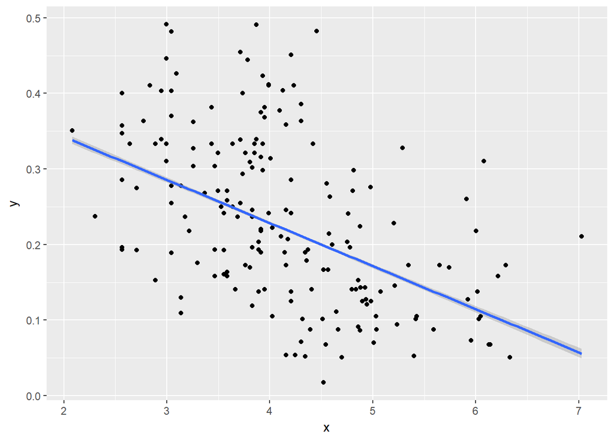

```r
my_data <- beginningReaders %>%
  select(., x = LogFrequency, y =  ProportionOfErrors)

my_data %>%
  ggplot(., aes(x = x, y = y)) +
    geom_point() +
    geom_smooth(method = 'lm')
```

# Model

Here, using the framework and code that we used last week, I fit a model with the dataset.

```r
my_fit <- lm(y ~ x, data = my_data)
summary(my_fit)
```

```
##
## Call:
## lm(formula = y ~ x, data = my_data)
##
## Residuals:
##      Min       1Q   Median       3Q      Max
## -0.18120 -0.06600 -0.01249  0.06512  0.27955
##
## Coefficients:
##              Estimate Std. Error t value Pr(>|t|)
## (Intercept)  0.456670   0.004781   95.52   <2e-16 ***
## x           -0.057040   0.001106  -51.59   <2e-16 ***
## ---
## Signif. codes:  0 '***' 0.001 '**' 0.01 '*' 0.05 '.' 0.1 ' ' 1
##
## Residual standard error: 0.09351 on 7921 degrees of freedom
## Multiple R-squared:  0.2515, Adjusted R-squared:  0.2514
## F-statistic:  2661 on 1 and 7921 DF,  p-value: < 2.2e-16
```

```r
confint(my_fit)
```

```
##                  2.5 %      97.5 %
## (Intercept)  0.4472981  0.46604146
## x           -0.0592077 -0.05487276
```

Their data were seemingly random; however, with the fitting of the line, there seems to be a negative correlation. That is, as the frequency of the word increasses, there seems to be less error in readability. This is understandable, as the more frequent something appears, the less foreign it seems to the agent of the situation.

Slope: -0.0570402

```r
coefficients(my_fit)
```

```
## (Intercept)           x
##  0.45666980 -0.05704023
```

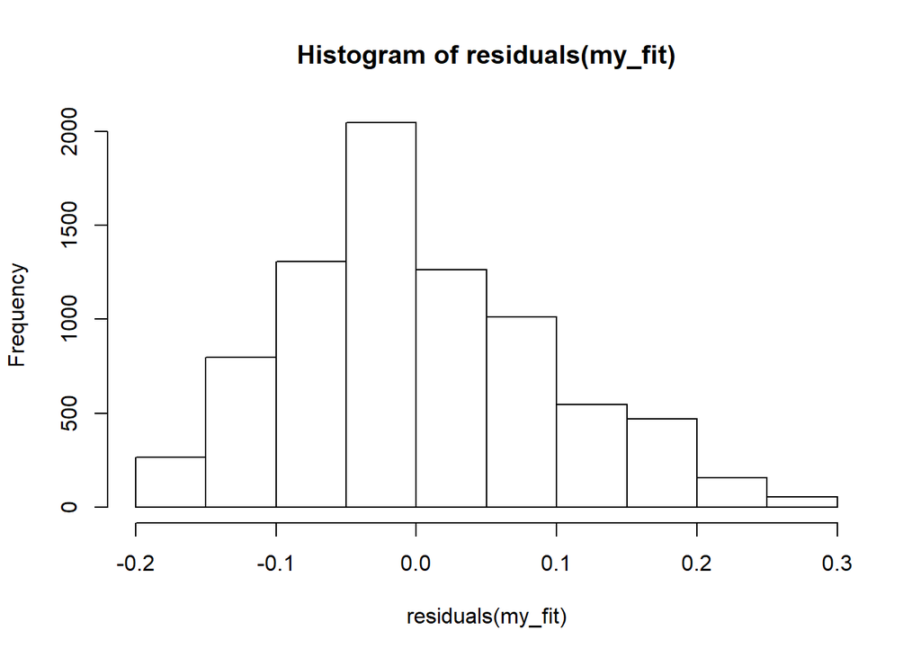

```r
hist(residuals(my_fit))
```

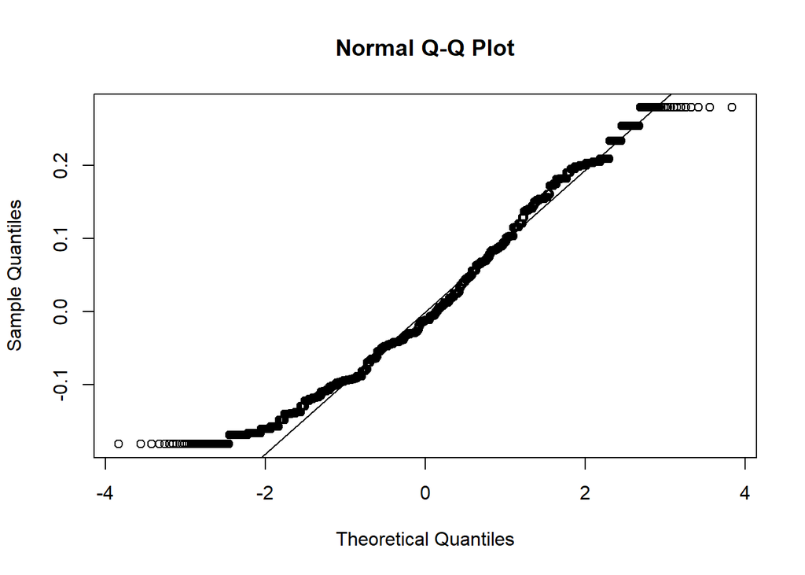

```r
qqnorm(residuals(my_fit))
qqline(residuals(my_fit))
```

```r
my_data %>%
  summary(.)
```

```
##        x               y
##  Min.   :2.079   Min.   :0.01754
##  1st Qu.:3.584   1st Qu.:0.13793
##  Median :4.143   Median :0.19643
##  Mean   :4.218   Mean   :0.21607
##  3rd Qu.:4.860   3rd Qu.:0.29825
##  Max.   :7.029   Max.   :0.49123
```